# ProjectB - R U Kidding? - Importance of attributes

Team 9: R U Kidding? Amy Maloche, Jake Fry, Shireen Zhou, Justin Mao, Delphine Ruaro

13 avril 2017

> In this file, we will be looking more closely at the 6 attributes individuals in the Speed Dating exercise where asked to rate: Attractiveness, Shared Interests, Ambition, Intelligence, Sincerity, Fun. We will be looking at the difference between males and females, assuming in the dataset all individuals where looking for a partner in the opposite sex.

## What do people look for in the other sex?

Here, we want to have a sense of what men and women say they look for in the opposite sex. Using the attributes, we will compare what they say they look for.

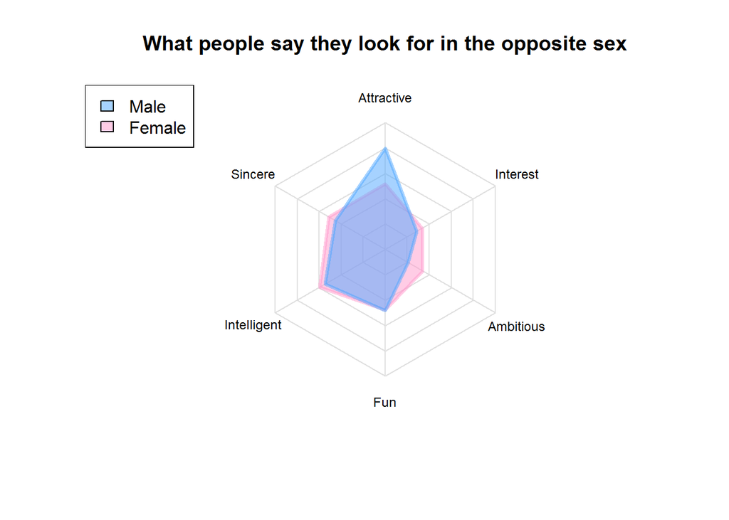

> We can see that men and women look for different attributes. Men seem to value attractiveness more than women do. On the other side, women seem to value sincerity and ambition more than men do. **Recommendation:** This implies that a predictive model should take gender into account, as the importance of attributes differ across genders.

## Which attributes actually matter

We will now try and understand which attributes *actually* mattered in people’s decision. Indeed, individuals can claim they are looking for a specific type of person, while in the end positively rating people with different attributes. In order to visualize this, we will use the attributes rating of people’s partner and their final decision. We will then look at the correlation between each attribute and the decision, on average and then by gender.

```
## Source: local data frame [441 x 4]
## Groups: pid [441]
##
##      pid gender  Decision Attractive
##    <int> <fctr>     <dbl>      <dbl>
## 1      1      1 0.5000000   6.700000
## 2      2      1 0.6000000   7.700000
## 3      3      1 0.4444444   6.555556
## 4      4      1 0.6000000   7.000000
## 5      5      1 0.3000000   5.300000
## 6      6      1 0.5000000   6.800000
## 7      7      1 0.7000000   7.900000
## 8      8      1 0.7777778   8.111111
## 9      9      1 0.7000000   7.000000
## 10    10      1 0.3750000   6.375000
## # ... with 431 more rows
```

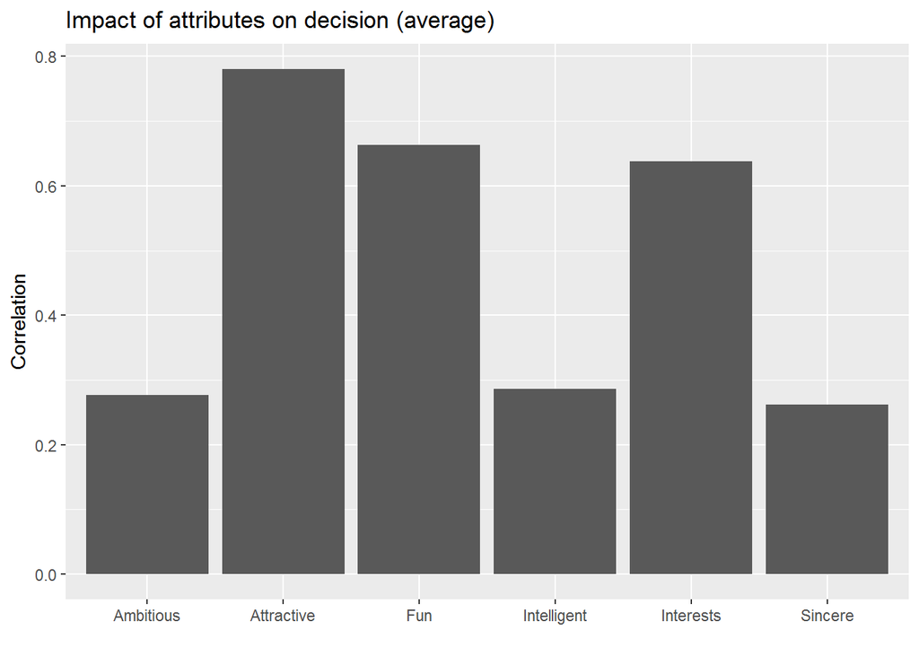

> We find that attractiveness, fun and shared interests are the most important attributes by far (~ 0.78, 0.67 and 0.63 respectively versus ~ 0.27 for the rest of attributes).

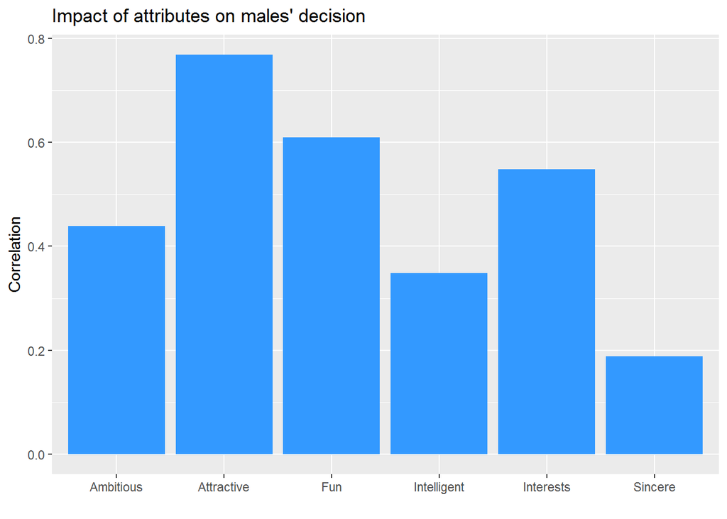

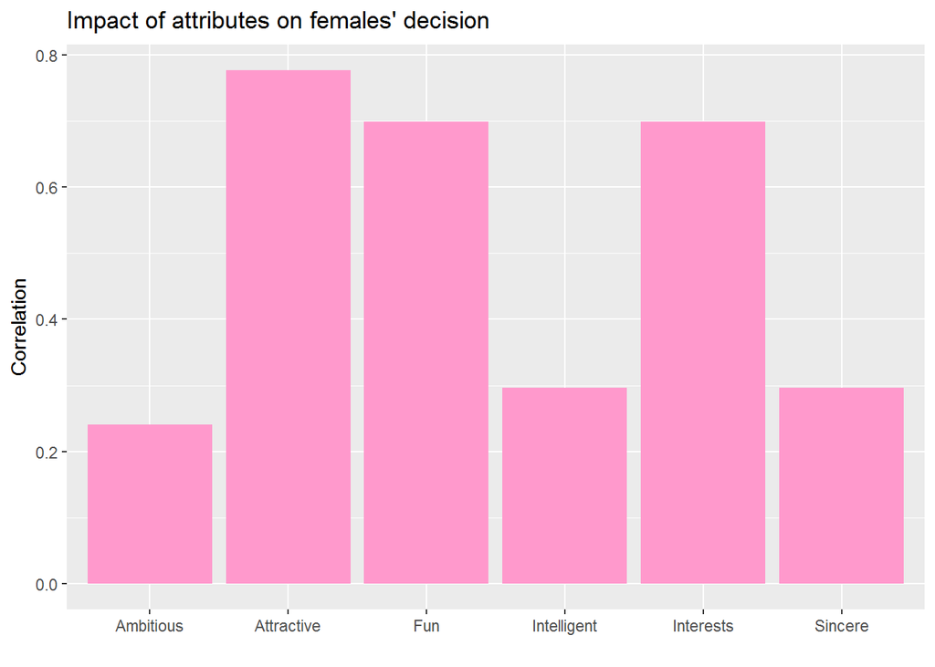

> When looking at the gender difference, we can see that ambition in a partner mattered more for men than for women, but that sincerity mattered less. Women, on the other side, look for fun in their partner more than men do.

## What do people say they want versus What they actually want

To visualize our latest findings more clearly, we will now compare what men and women said they were looking for in a partner versus what they actually cared about. The first one refers to their stated preferences, while the second one refers to the correlation between their decision and their rating of partners.

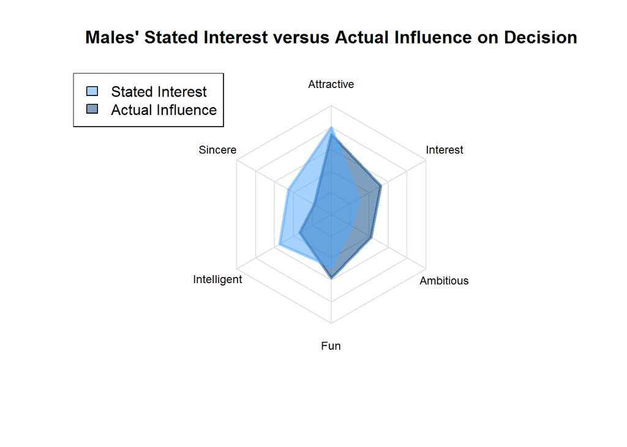

> We can see that men value ambition and shared interests in women more than they say they do. On the other hand, intelligence did not influence their decision that much.

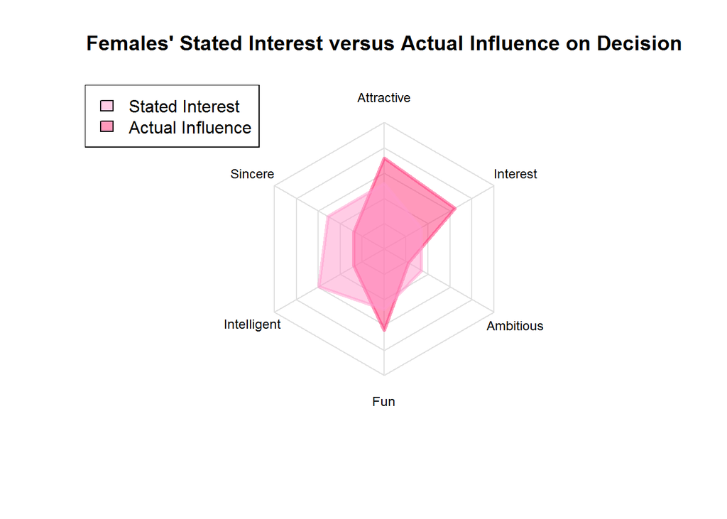

> Women value attractiveness, fun and shared interests much more than they say they do. As for men, intelligence and sincerity did not influence their decision that much.

> **Recommendation:** It seems like intelligence does not influence people’s decision that much. We would therefore suggest not ask any academic-related question in the signup process. In order to increase people’s chances of being asked on a date, we would also suggest **helping them in the signup process**. Indicating what the other sex looks for in a partner could indeed help them filling their profile and choosing their profile picture accordingly. For example, men could be thinking a serious profile would give them more chances, while data shows women prefer fun in a man.

> Overall, we can now clearly see that people’s stated interest versus their actual preferences highly differs. **Recommendation:** this suggests that the matching algorithm should not take users’ stated preferences so much into account, but rather use historical data on the attributes of individuals this user decided to go on a date with (in the case of Tinder, “swiped right”). As an additional recommendation, we could argue that asking users the attributes they look for in a partner is useless, and can be avoided in order to make the signup process easier. This would, indeed, increase the conversion rate and reduce abandons on the platform.

## What people think the opposite sex wants versus what the opposite sex really wants:

We will now look at the difference between what individuals think the opposite sex looks for in a partner, compared to what they actually do.

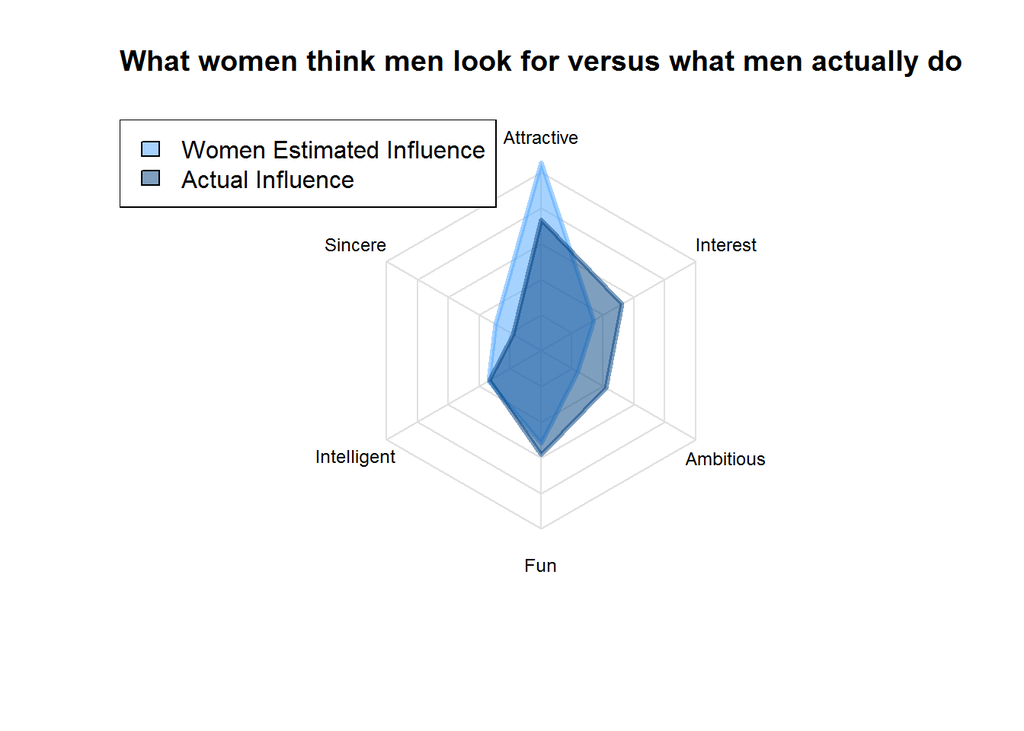

> We can see that women think men care about attractiveness a lot more than what they actually do. On the other hand, they underestimate the importance of shared interests and ambition.

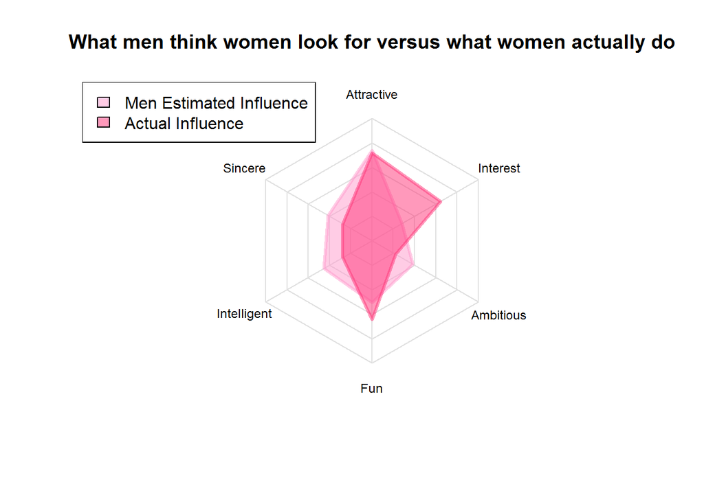

> Men have a good understanding of how much women value attractiveness. However, they underestimate the importance of shared interests and fun.

> Overall, this shows that people have wrong perceptions of what the opposite sex looks for in a partner. In the context of online dating, this could suggest that users would do a poor job at completing their profile, by making wrong assumptions on what will be seen as attractive. For example, a man could overestimate the importance of ambition compared to fun, and display a very serious resume-like profile, rather than posting a casual, fun picture that would get him more matches.

> **Recommendation:** We recommend helping users filling up their profile by using our data on what both genders look for in the opposite sex. When users would log in, they could have tips on what is seen as more attractive, and what they should emphasize on.

## Impact of number of previous dates

We will now analyze the impact of the number of dates on people’s decision. To do that, we will look at the ratio of positive decision after first dates compared to after the last dates (usually, the 10th date in this dataset).

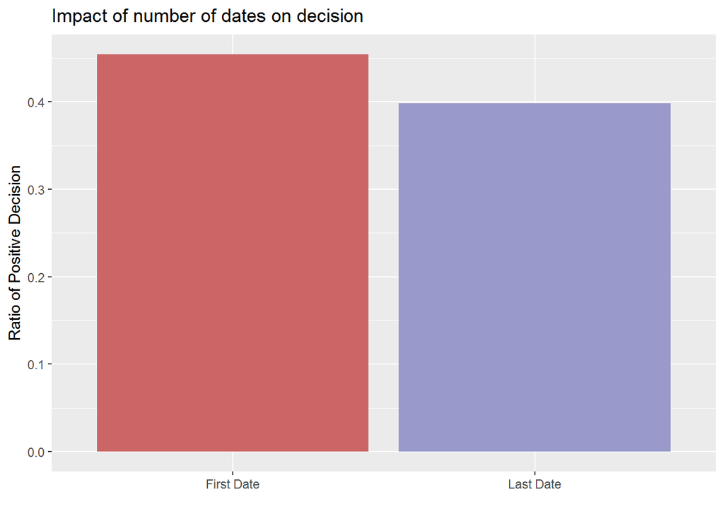

> After multiple dates, people were more difficult, and said “yes” to less people. This means that the number of previous dates impacts the likelihood of matching. **Recommendation:** we would suggest to increase the required accuracy of the model for people that have been on multiple dates already. If someone has been on multiple dates through the app already, the suggested profiles for that person should match his/her “perfect partner” even more. This implies that the app should track which matches converted into dates.